# TestAssignment

Are there differences in activity patterns between weekdays and weekends?

- Create a new factor variable in the dataset with two levels – “weekday” and “weekend” indicating whether a given date is a weekday or weekend day.

```r
df1$day=ifelse(as.POSIXlt(as.Date(df1$date))$wday%%6==0,                      "weekend","weekday")
```

- Make a panel plot containing a time series plot (i.e. type = “l”) of the 5-minute interval (x-axis) and the average number of steps taken, averaged across all weekday days or weekend days (y-axis). The plot should look something like the following, which was creating using simulated data:

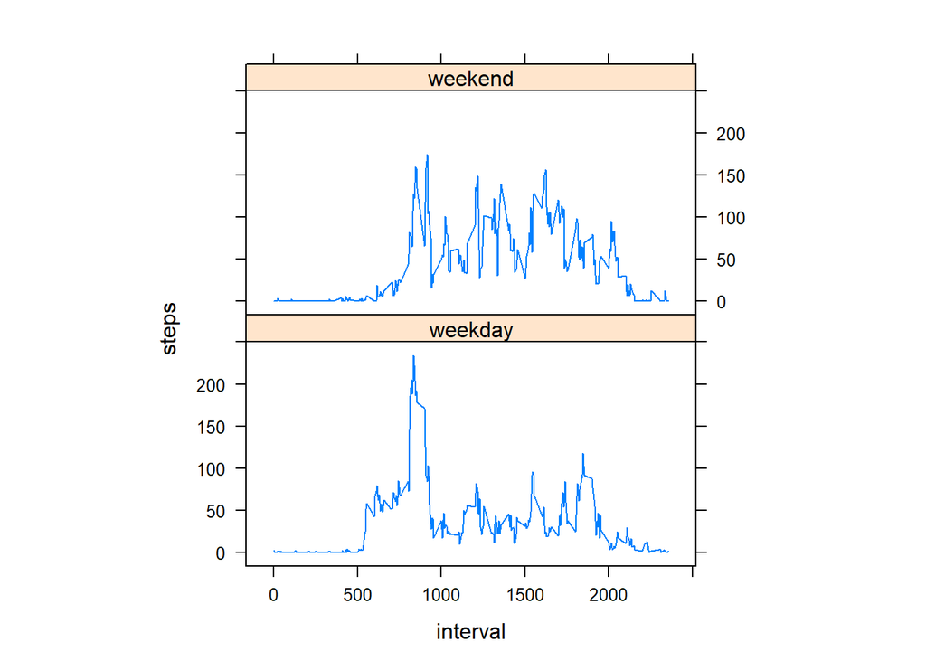

```r
stepsInterval2=aggregate(steps~interval+day,df1,mean)

library(lattice)

xyplot(steps~interval|factor(day),data=stepsInterval2,aspect=1/2,type="l")
```

- Another plot using ggplot system

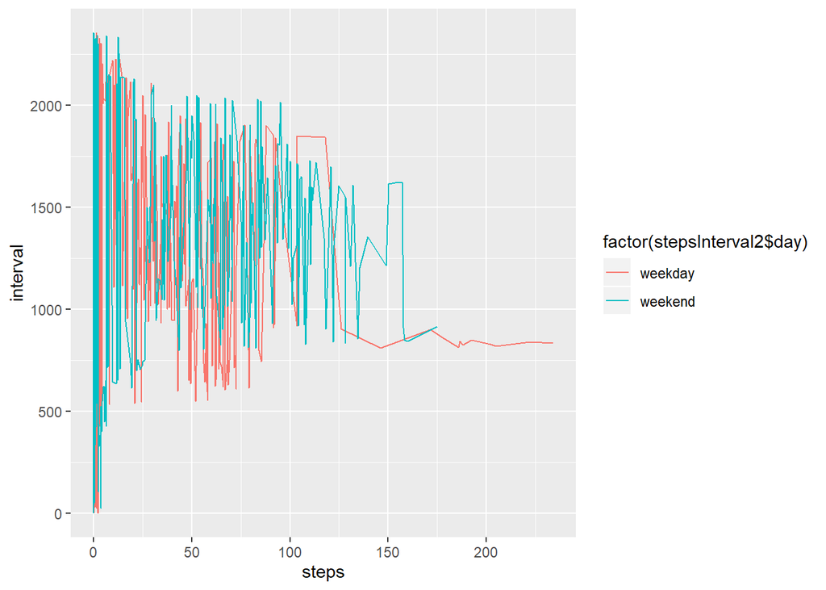

```r
stepsInterval2=aggregate(steps~interval+day,df1,mean)

library(ggplot2)

g <- ggplot(stepsInterval2, aes(x = steps, y = interval))
g <- g + geom_line(aes(col=factor(stepsInterval2$day)))

g
```